# P1-Test a Perceptual Phenomenon

Author: Chenjun Ling

## Background: Stroop task

In a Stroop task, participants are presented with a list of words, with each word displayed in a color of ink. The participant’s task is to say out loud the color of the ink in which the word is printed. The task has two conditions: a congruent words condition, and an incongruent words condition. In the **congruent** words condition, the words being displayed are color words whose names match the colors in which they are printed: for example RED, BLUE. In the **incongruent** words condition, the words displayed are color words whose names do not match the colors in which they are printed: for example PURPLE, ORANGE. In each case, we measure the time it takes to name the ink colors in equally-sized lists. Each participant will go through and record a time from each condition. [Details](https://docs.google.com/document/d/1-OkpZLjG_kX9J6LIQ5IltsqMzVWjh36QpnP2RYpVdPU/pub?embedded=True)

## Statistical Analysis Results

#### 1. What is our independent variable? What is our dependent variable?

Answer: Independent--word conditions (Congruent or Incongruent); Dependent--participant respond time

#### 2. What is an appropriate set of hypotheses for this task? What kind of statistical test do you expect to perform? Justify your choices.

\(\mu_c\): congruent words mean respond time; \(\mu_i\): incongruent words mean respond time

Based on the alternative hypothesis, I will conduct upper-tailed t test

#### 3. Report some descriptive statistics regarding this dataset. Include at least one measure of central tendency and at least one measure of variability.

```python
import os
import pandas as pd
path =os.getcwd()
print path
df = pd.read_csv(path + '/rawdata/stroopdata.csv')
print "The data we have:\n"
df
```

```
F:\Personal\Udacity-Data-Analyst-Nanodegree\P1-TestAPerceptualPhenomenon
The data we have:
```

|  | Congruent | Incongruent |
| --- | --- | --- |
| 0 | 12.079 | 19.278 |
| 1 | 16.791 | 18.741 |
| 2 | 9.564 | 21.214 |
| 3 | 8.630 | 15.687 |
| 4 | 14.669 | 22.803 |
| 5 | 12.238 | 20.878 |
| 6 | 14.692 | 24.572 |
| 7 | 8.987 | 17.394 |
| 8 | 9.401 | 20.762 |
| 9 | 14.480 | 26.282 |
| 10 | 22.328 | 24.524 |
| 11 | 15.298 | 18.644 |
| 12 | 15.073 | 17.510 |
| 13 | 16.929 | 20.330 |
| 14 | 18.200 | 35.255 |
| 15 | 12.130 | 22.158 |
| 16 | 18.495 | 25.139 |
| 17 | 10.639 | 20.429 |
| 18 | 11.344 | 17.425 |
| 19 | 12.369 | 34.288 |
| 20 | 12.944 | 23.894 |
| 21 | 14.233 | 17.960 |
| 22 | 19.710 | 22.058 |
| 23 | 16.004 | 21.157 |

```python
print "The mean respond time of congruent and incongruent:\n"
df.mean()
```

```
The mean respond time of congruent and incongruent:
```

```
Congruent      14.051125
Incongruent    22.015917
dtype: float64
```

```python
print "The standard deviations of the respond time of congruent and incongruent words:\n"
df.std()
```

```
The standard deviations of the respond time of congruent and incongruent words:
```

```
Congruent      3.559358
Incongruent    4.797057
dtype: float64
```

#### 4. Provide one or two visualizations that show the distribution of the sample data. Write one or two sentences noting what you observe about the plot or plots.

```
Figure 1:
```

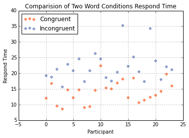

```python
import matplotlib.pyplot as plt
import brewer2mpl

# Get "Set2" colors from ColorBrewer (all colorbrewer scales: http://bl.ocks.org/mbostock/5577023)

print "Figure 1:\n"
set2 = brewer2mpl.get_map('Set2', 'qualitative', 8).mpl_colors

# Have mathplotlib put all plots into the notebook instead of
# in a seperate window.
%matplotlib inline

samplesize=len(df)
index = range(samplesize)
plt.scatter(x=index, y=df['Congruent'], color = set2[1], label='Congruent')
plt.scatter(x=index, y=df['Incongruent'], color = set2[2], label='Incongruent')
plt.legend(loc=2)
plt.xlabel("Participant")
plt.ylabel("Respond Time")
plt.title("Comparision of Two Word Conditions Respond Time")
plt.grid()
plt.show()
```

```
Figure 2:
```

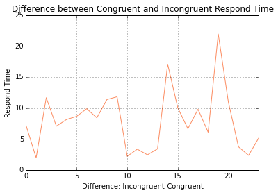

```python
print "Figure 2:\n"

df['Difference'] = df['Incongruent'] - df['Congruent']
plt2 = df['Difference'].plot(kind='line', grid=True, color = set2[1])
plt2.set_title('Difference between Congruent and Incongruent Respond Time')
plt2.set_xlabel('Difference: Incongruent-Congruent')
plt2.set_ylabel('Respond Time')
```

```python
print "Difference mean:\n"
df['Difference'].mean()
```

```
Difference mean:
```

```
7.964791666666667
```

```python
print "Difference standard deviation:\n"
df['Difference'].std(axis=0)
```

```
Difference standard deviation:
```

```
4.864826910359056
```

Answer: As we can see these two plot, I put in two word conditions data to compare in the first one, and the difference of incongruent time minus congruent time is the second one. The time of incongruent time basically higher than congruent time (we can get the generally difference in the first figure, make sure from the second figure since the values are all positive), and there are two extremly high incongruent times arond participant 14 and 19.

#### 5. Now, perform the statistical test and report your results. What is your confidence level and your critical statistic value? Do you reject the null hypothesis or fail to reject it? Come to a conclusion in terms of the experiment task. Did the results match up with your expectations?

Confidence Level: 95%, so \(\alpha\)=0.05

Degree of Freedom (DF): 24-1=23

T-critical value: based on the t table, is 1.714

T-statistic value: (\(\mu_i\)-\(\mu_c\))/SEM = (\(\mu_d\)-0)/(\(s_d\)/ \(\sqrt(n)\)) = 7.97/(4.8648/\(\sqrt(24)\)) = 8.02

Reject the null hypothesis: since I conduct upper-tailed t-test, the reject region is the upper regeion. Because t-statistic value > t-critical value, and p < 0.05, I will reject the null hypothesis, and it match up with my expectation.

### References

[1] prettyplotlib: http://blog.olgabotvinnik.com/blog/2013/08/21/2013-08-21-prettyplotlib-painlessly-create-beautiful-matplotlib/

[2] ttable: https://s3.amazonaws.com/udacity-hosted-downloads/t-table.jpg

[3] Hypothesis Testing: Upper-, Lower, and Two Tailed Tests: http://sphweb.bumc.bu.edu/otlt/MPH-Modules/BS/BS704_HypothesisTest-Means-Proportions/BS704_HypothesisTest-Means-Proportions3.html